# Lab 02 - Constructing Groups

Phani Srija Kesara

04 September, 2024

# Data

The following report identifies specific tax parcels in Downtown Syracuse, New York (USA).

View the dataset documentation here: [Syracuse, NY Tax Parcel Data](https://watts-college.github.io/cpp-526-fall-2022/labs/syr_parcels.html).

## Required Packages

The following packages are required for this report and loaded with `library()`.

```r
library(sp)
library(rgdal)
library(geojsonio)                            # Load required libraries
```

## Import Spatial Polygons

We read in spatial polygons (`"sp"`) with function `geojson_read()` to map tax parcel shapes in Syracuse’s Downtown area.

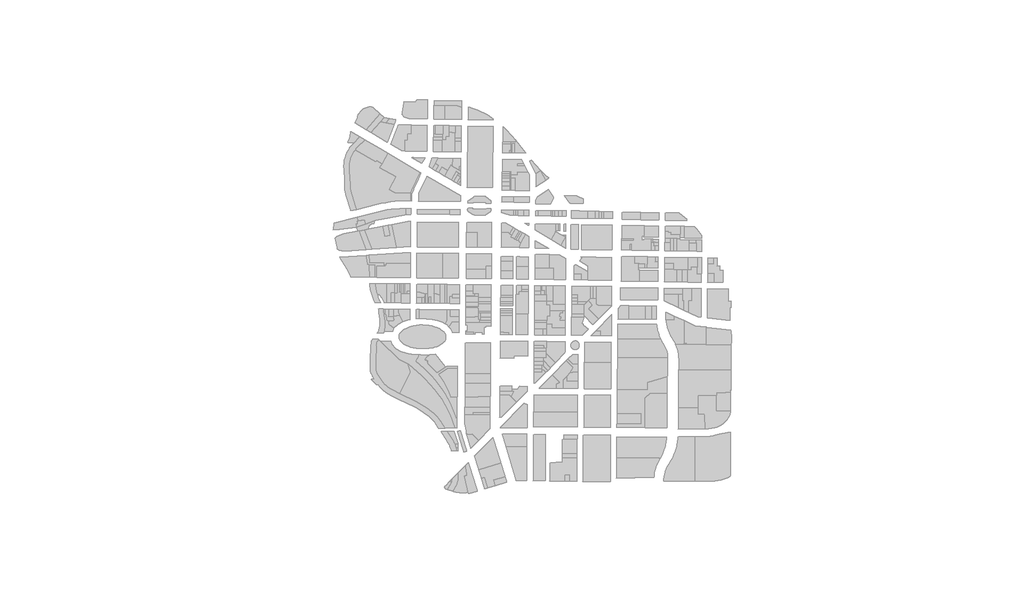

```r
install.packages("https://cran.r-project.org/bin/windows/contrib/4.1/rgdal_1.6-6.zip", repos = NULL, type = "binary")

url <- paste0("https://raw.githubusercontent.com/DS4PS/Data",
              "-Science-Class/master/DATA/downtown-syr.geojson")

downtown <- geojson_read(url, what = "sp")    # Load parcel data

plot(downtown,
     border = "gray60",
     col = "gray80")                          # Visualize parcels
```

# Example Solutions

The following examples demonstrate how to use conditions to identify specific parcels.

### Example: Tax Parcel Acres

Parcels with more than one acre are determined with variable `acres` and condition `> 1`.

```r
result <- downtown$acres > 1                  # Each value in 'acres' is tested
```

All `TRUE` and `FALSE` values, for each parcel, are converted into colors.

```r
group.colors <- ifelse(test = result,         # 'test =' accepts TRUE or FALSE values
                       yes = "firebrick",     # 'yes =' converts values that are TRUE
                       no = "gray80")         # 'no =' converts values that are FALSE
```

All tax parcels in `downtown` are mapped with `plot()`. Each parcel has one of two colors per the above code.

[figure not shown]

```r
plot(downtown,                                # Plots object 'downtown'
     border = NA,
     col = group.colors)                      # Red when TRUE; gray when FALSE
```

### Example: Parcels with Single Families

Use variable `landuse` to determine how a tax parcel is used. Determine all possible values with `unique()`.

```r
unique(downtown$landuse)                      # All unique values in 'landuse'
```

```
##  [1] "Parking"            "Commercial"         "Parks"
##  [4] "Community Services" "Vacant Land"        "Utilities"
##  [7] "Apartment"          "Recreation"         "Schools"
## [10] "Religious"          "Industrial"         "Single Family"
```

One of the values in `landuse` is “Single Family”. Therefore, the test is whether or not `landuse` is exactly equal to “Single Family”.

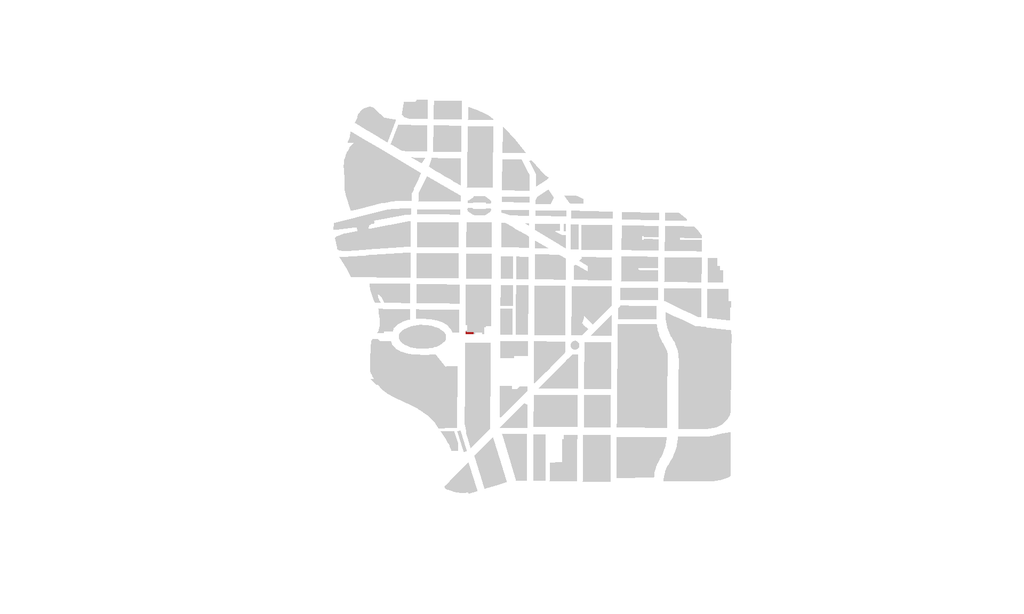

```r
result <- downtown$landuse == "Single Family" # Test if 'landuse' is "Single Family"

group.colors <- ifelse(test = result,         # Provide TRUE or FALSE test results
                       yes = "firebrick",     # If TRUE, make "firebrick"
                       no = "gray80")         # If FALSE, make "gray80"

plot(downtown,
     border = NA,
     col = group.colors)                      # Plot with respective colors
```

# Questions & Solutions

The following questions ask you to map your results, write your answer, or both. The first question has been completed for you.

## Question 1: Vacant Lots

**Question:** *Where are the majority of vacant lots located in downtown Syracuse? Map your results.*

**Note:** *This solution has been provided for you.*

```r
unique(downtown$landuse)                      # Print unique values in 'landuse'
```

```
##  [1] "Parking"            "Commercial"         "Parks"
##  [4] "Community Services" "Vacant Land"        "Utilities"
##  [7] "Apartment"          "Recreation"         "Schools"
## [10] "Religious"          "Industrial"         "Single Family"
```

Now, we create our test statement, `== "Vacant Land"`, and store the results in `result`.

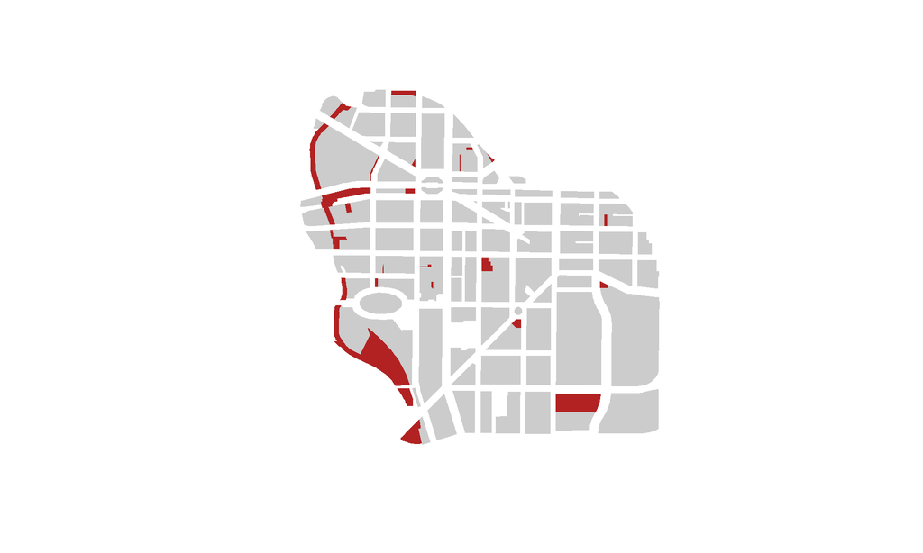

```r
result <- downtown$landuse == "Vacant Land"

group.colors <- ifelse(test = result,
                       yes = "firebrick",
                       no = "gray80")

plot(downtown,
     border = NA,
     col = group.colors)
```

## Question 2: Parking Lots

**Question:** *How many parking lots are in downtown Syracuse? Map your results.*

**Answer:** There are 78 parking lots in downtown Syracuse.

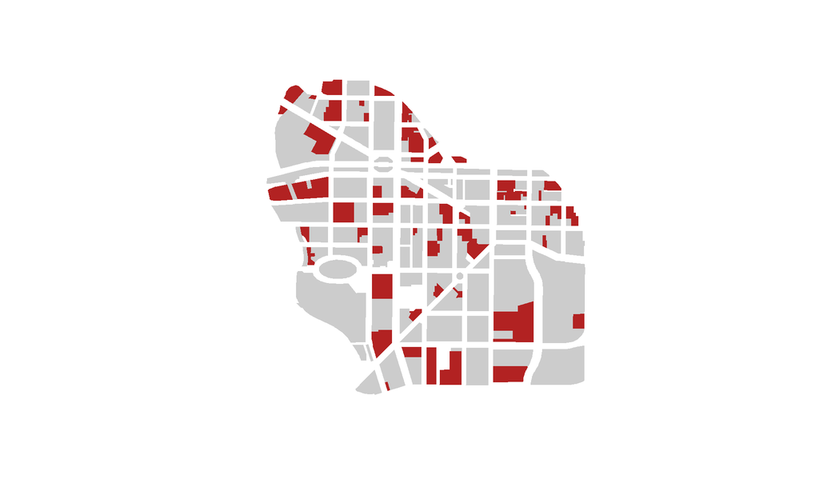

```r
# Use function: 'sum()'
# Use variable: 'landuse'

# Assign test (logical) output to object 'result' by replacing 'FALSE'

parking.lots <- sum(downtown$landuse == "Parking")


result <- downtown$landuse == "Parking"

group.colors <- ifelse(test = result,
                       yes = "firebrick",
                       no = "gray80")

plot(downtown,
     border = NA,
     col = group.colors)
```

## Question 3: New Construction

**Question:** *Where is new construction located in the city? Map your results.*

**Answer:** There are 29 buildings constructed after 1980.

**Note:** You may use `>=` (greater than or equal) or `>` (greater than) 1980.

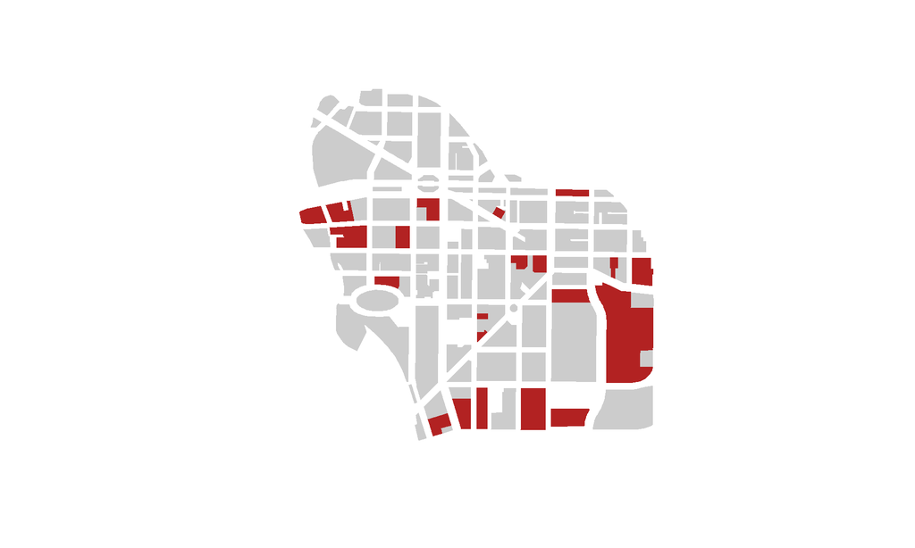

```r
# Use variable: 'yearbuilt'
# Find the number of buildings constructed either after or during and after than 1980

# Assign test (logical) output to object 'result' by replacing 'FALSE'

new.building <- sum(downtown$yearbuilt > 1980, na.rm = TRUE)


result <- downtown$yearbuilt > 1980

group.colors <- ifelse(test = result,
                       yes = "firebrick",
                       no = "gray80")

plot(downtown,
     border = NA,
     col = group.colors)
```

**Question:** *What proportion of commercial properties are built since 1980?*

**Answer:** **14.3540%** of commercial properties were built since 1980.

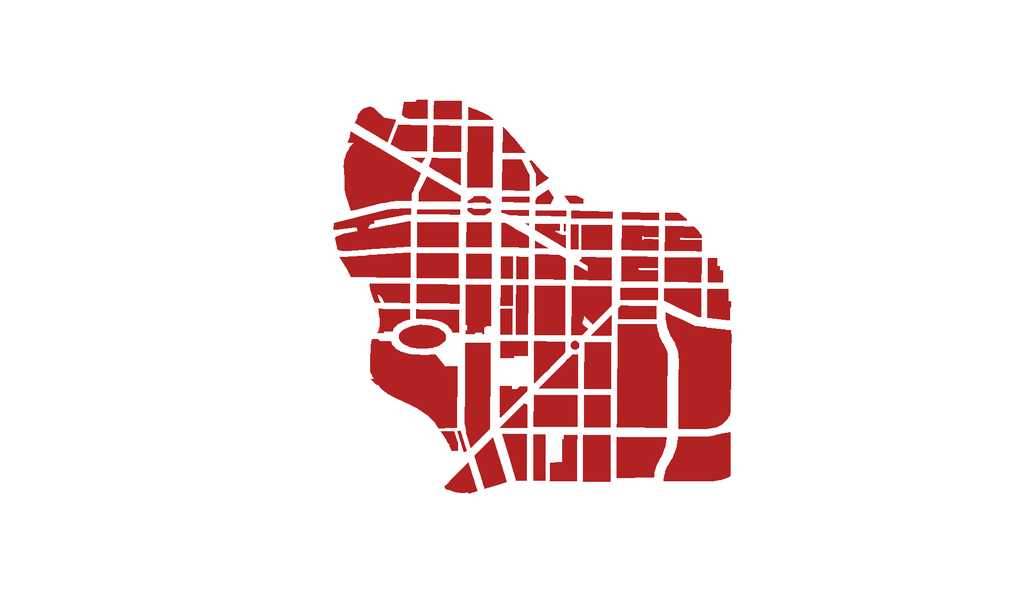

```r
# Use variable: 'landuse'
# Use variable: 'yearbuilt'
# Count only commercial properties with buildings constructed during or later than 1980

commercial.properties <- downtown[downtown$landuse == "Commercial", ]

total.commercial <- nrow(commercial.properties)

commercial.after.1980 <- sum(commercial.properties$yearbuilt >= 1980, na.rm = TRUE)

proportion.commercial.after.1980 <- (commercial.after.1980 / total.commercial) * 100

result <- commercial.after.1980

group.colors <- ifelse(test = result,
                       yes = "firebrick",
                       no = "gray80")

plot(downtown,
     border = NA,
     col = group.colors)
```

## Question 4: Parcels Valued Over $10M

**Question:** *How many parcels have assessed values over $10 million? Map your results.*

**Answer:** **16** parcels have assessed values over $10 M.

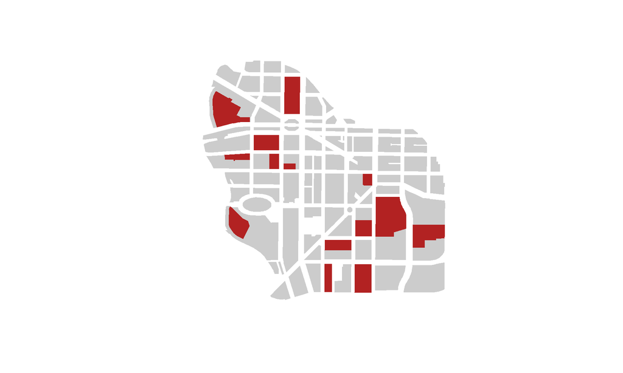

```r
# Use function: 'sum()'
# Use variable: 'assessedval'

# Assign test (logical) output to object 'result' by replacing 'FALSE'

parcel.over.10M <- sum(downtown$assessedval > 10000000, na.rm = TRUE)

result <- downtown$assessedval > 10000000

group.colors <- ifelse(test = result,
                       yes = "firebrick",
                       no = "gray80")

plot(downtown,
     border = NA,
     col = group.colors)
```

## Question 5: Total Tax Delinquent Parcels

**Question:** *How many properties are delinquent on taxes? Map your results.*

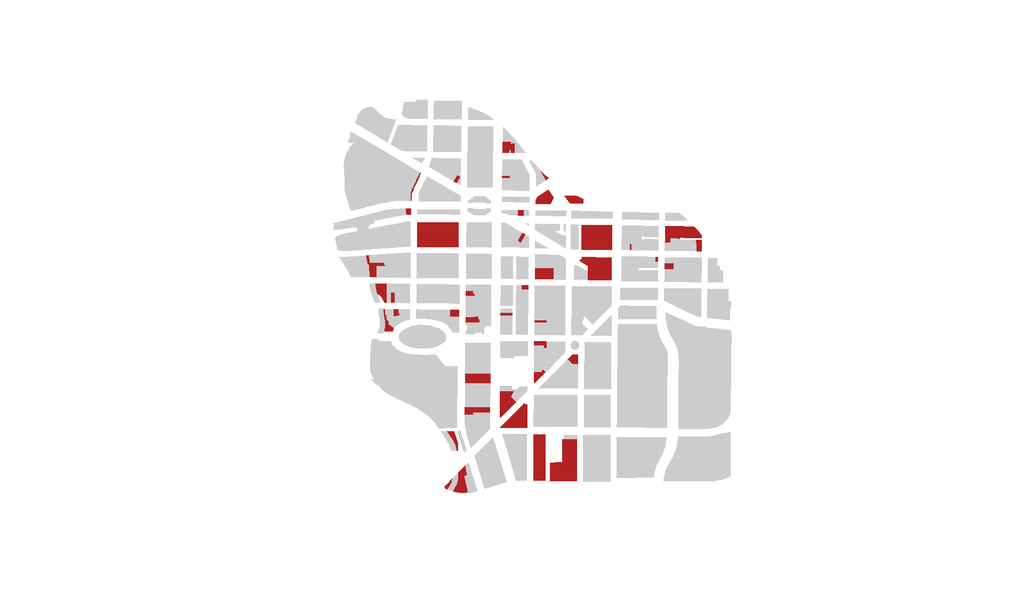

```r
# Use function: 'sum()'
# Use variable: 'amtdelinqt'

# Assign test (logical) output to object 'result' by replacing 'FALSE'

delinquent.count <- sum(downtown$amtdelinqt > 0, na.rm = TRUE)

result <- downtown$amtdelinqt >0

group.colors <- ifelse(test = result,
                       yes = "firebrick",
                       no = "gray80")

plot(downtown,
     border = NA,
     col = group.colors)
```

## Question 6: Tax Delinquent Parcels

**Question:** *What proportion of parcels have delinquent tax payments owed?*

**Answer:** **[14.653%]** of parcels have delinquent tax payments owed.

```r
# Use function: 'mean()'
# Use variable: 'amtdelinqt'

delinquent.proportion <- mean(downtown$amtdelinqt > 0, na.rm = TRUE) * 100
```

## Question 7: Tax Delinquent Commercial Properties

**Question I:** *What proportion of commercial properties are delinquent on taxes?*

**Question II:** *What proportion of delinquent tax bills are owed by commercial parcels?*

**Answer I:** **11.9617%** of commercial properties are delinquent on taxes.

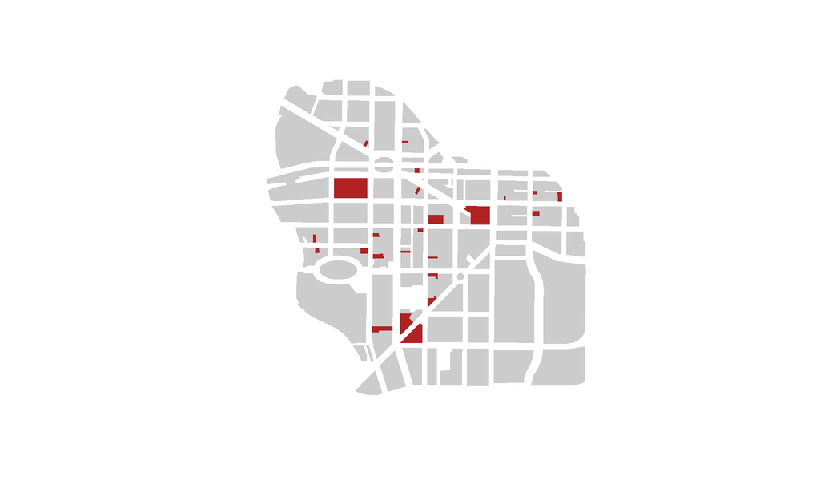

```r
# Use function: 'mean()'
# Use variable: 'amtdelinqt'
# Use variable: 'landuse'

# The first answer is tax-delinquent commercial properties over all commercial properties

commercial.delinquent.proportion <- mean(commercial.properties$amtdelinqt > 0, na.rm = TRUE) * 100

result <- (downtown$landuse == "Commercial") & (downtown$amtdelinqt > 0)

group.colors <- ifelse(test = result,
                       yes = "firebrick",
                       no = "gray80")

plot(downtown,
     border = NA,
     col = group.colors)
```

```r
# The second answer is the tax dollars owed by commercial properties (a subset) over all tax dollars owed

total.delinquent <- sum(downtown$amtdelinqt, na.rm = TRUE)

commercial.delinquent.amount <- sum(commercial.properties$amtdelinqt, na.rm = TRUE)

delinquent.amount.commercial.proportion <- (commercial.delinquent.amount / total.delinquent) * 100

delinquent.amount.commercial.proportion
```

```
## [1] 86.95747
```

## Question 8: Tax Delinquent Parcels by Land Use

**Question:** *How many of each land use type are delinquent on taxes? Print a table of your results.*

```r
# Use function: 'table()'
# Use variable: 'amtdelinqt'
# Use variable: 'landuse'

delinquent <- downtown$amtdelinqt > 0

delinquent.by.landuse <- table(downtown$landuse[delinquent])

delinquent.by.landuse
```

```
##
##         Commercial Community Services         Industrial            Parking
##                 25                  2                  2                 16
##        Vacant Land
##                 12
```